# Evoluzione della Telefonia

## Analisi delle vendite e delle tendenze di mercato

Alice Blandino, 163002  
Progetto di data-science

# Perchè questo progetto?

Gli smartphone sono dispositivi fondamentali.  
Vogliamo capire quali modelli dominano il mercato e perché.  
L’analisi dei dati ci aiuterà a scoprire quali fattori influenzano le vendite.

## Domande chiave

1. Come si sono evolute le vendite di smartphone nel tempo?
2. Qual è il telefono più venduto di sempre? E per gli smartphone?
3. Qual è la relazione tra il produttore (marca) e il numero di unità vendute?
4. C'è una correlazione tra l'introduzione degli smartphone e l'abbandono dei non-smartphone?
5. Quali marche dominano il mercato degli smartphone e quale tipo di telefono producono?

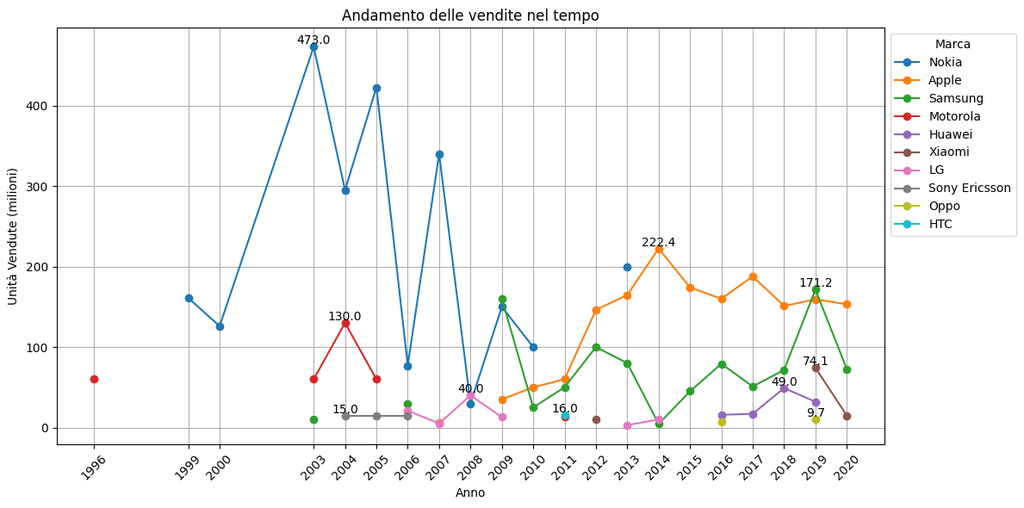

# Dataset utilizzato

Il dataset principale contiene informazioni sui telefoni, con le seguenti colonne:

- Marca (Apple, Samsung, Xiaomi…);
- Modello;
- Form-factor;
- Anno di uscita;
- Unità vendute.

|  | Rank | Manufacturer | Model | Form Factor | Smartphone? | Year | Units Sold (million ) |
| --- | --- | --- | --- | --- | --- | --- | --- |
| 0 | 1 | Nokia | 1100 | Bar | False | 2003 | 250.0 |
| 1 | 2 | Nokia | 1110 | Bar | False | 2005 | 247.5 |
| 2 | 3 | Apple | iPhone 6 & 6 Plus | Touchscreen | True | 2014 | 222.4 |
| 3 | 4 | Nokia | 105 Series | Bar | False | 2013 | 200.0 |
| 4 | 5 | Apple | iPhone 6S & 6S Plus | Touchscreen | True | 2015 | 174.1 |
| 5 | 6 | Apple | iPhone 5S | Touchscreen | True | 2013 | 164.5 |
| 6 | 7 | Nokia | 3210 | Bar | False | 1999 | 161.0 |
| 7 | 8 | Apple | iPhone 7 & 7 Plus | Touchscreen | True | 2016 | 159.9 |
| 8 | 9 | Apple | iPhone11, 11Pro & 11Pro Max | Touchscreen | True | 2019 | 159.2 |
| 9 | 10 | Apple | iPhone XR, iPhone XS & iPhone XS Max | Touchscreen | True | 2018 | 151.1 |

Fonte: [kaggle](http://kaggle.com/datasets/muhammadroshaanriaz/global-best-selling-phone-sales?select=top+120+best-selling+mobile+phones.csv)  
Autore: Muhammad Roshan Riaz  
Ultimo update: 1 anno fa

### Il from factor

I telefoni presi in questione nel dataset sono:

**Bar**: telefono a barra.

[figure not shown]

**Keyboard bar**: telefono a barra con tastiera.

[figure not shown]

**Slider**: telefono con più parti.

[figure not shown]

**Taco**: chiamato così per la sua forma.

[figure not shown]

**flip-phone**: telefono pieghevole.

[figure not shown]

**Smartphones**: telefono con prestazioni elevate.

[figure not shown]

# Evoluzione delle vendite nel tempo

## Negli anni recenti, quali telefoni hanno venduto di più?

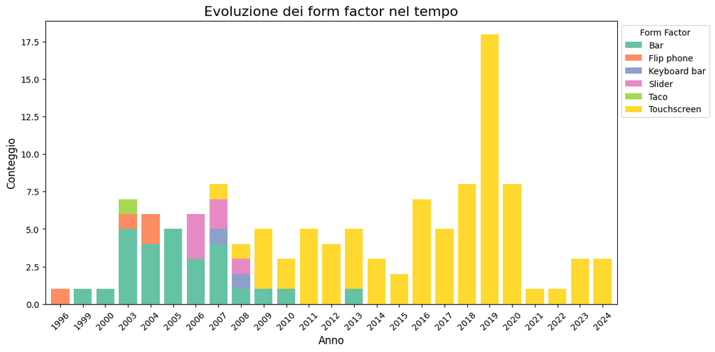

# Smartphone vs Feature Phone

## Non solo smartphones, ma chi ha venduto di più?

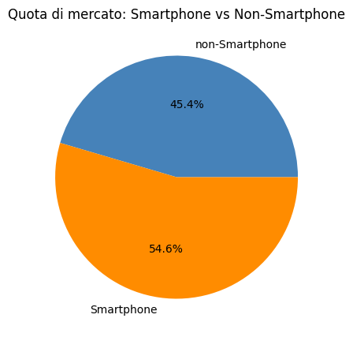

Hanno venduto di più gli **Smartphone**.

## E per quanto riguarda i non-Smartphone?

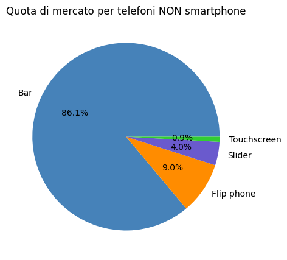

## Classifica separata per Feature Phone e Smartphone

Quali sono i telefoni più venduti per categoria? Abbiamo diviso la classifica in **Feature Phone** e **Smartphone**:

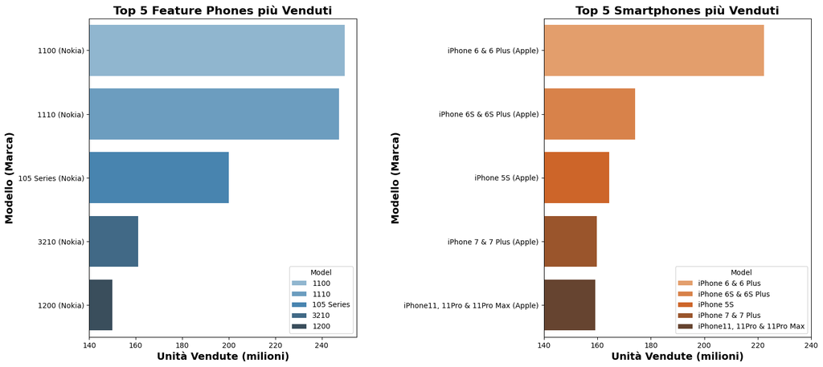

Il **feature Phones** più venduto è il **Nokia 1100(2003)**.  
Lo **smartphone** più venduto è **iPhone6 & 6 Plus (Apple)**.

# I brand con i telefoni più venduti

## Quale azienda ha dominato il mercato?

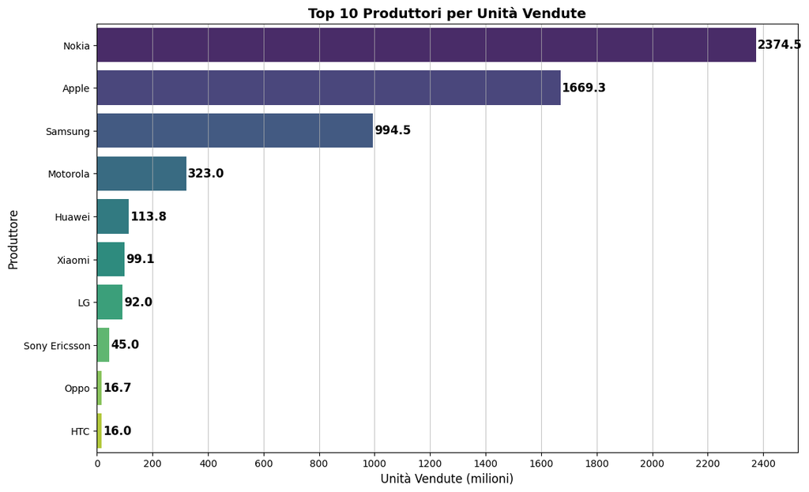

## E negli anni?

Andando più nello specifico ogni anno ha avuto un "vincitore".

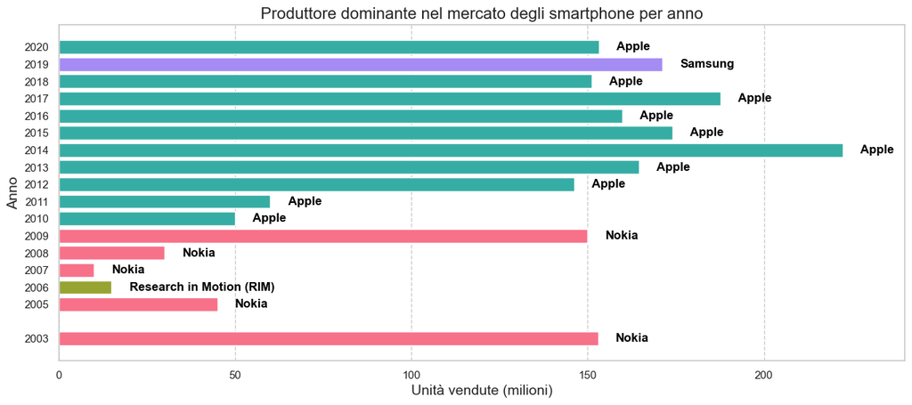

# Qual è il telefono più venduto della storia?

## Analizziamo il telefono con più unità vendute

Ordinati i dati per unità vendute, si ricava il marchio con il numero più alto di vendite:

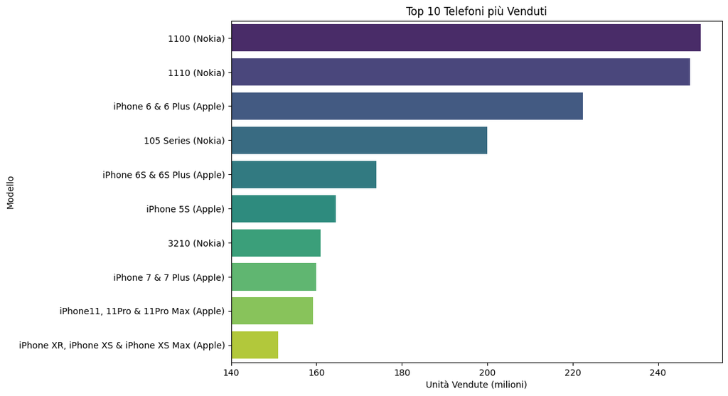

Il telefono più venduto è stato il **Nokia 1100 (2003)** con **250 milioni** di unità vendute.

## E per quanto riguarda gli smartphone?

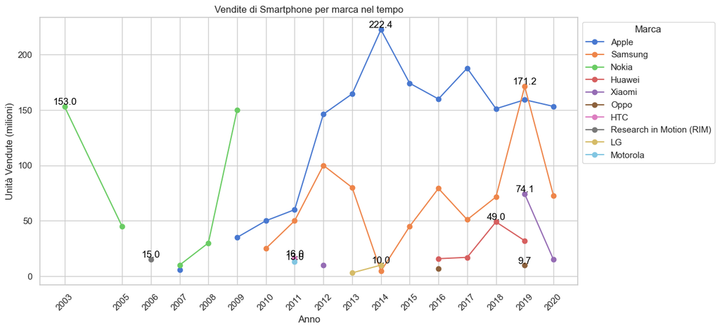

## Andando più nel dettaglio...

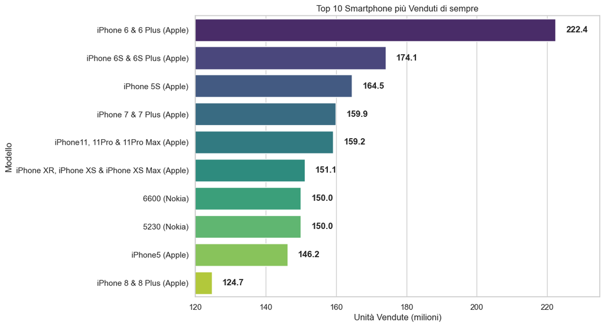

Lo smartphone più venduto di sempre è l'**iPhone6 & 6 Plus (Apple)** con **222.4 milioni** di vendite.

## E negli ultimi 5 anni?

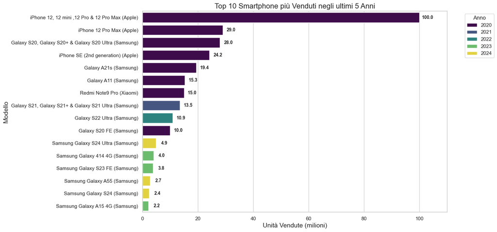

# Matrice di correlazione

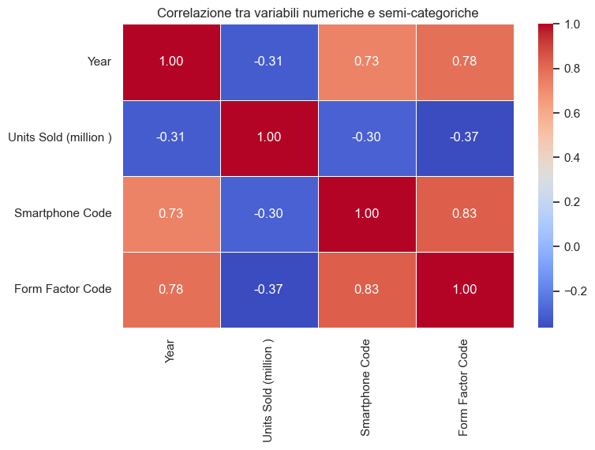

- Correlazione lievemente negativa tra **Anno e Unità Vendute**;
- Correlazione fortemente positiva tra **Anno e Smartphone**;
- Correlazione debolmente negativa tra **Smartphone e Unità Vendute**;
- Correlazione moderatamente negativa tra **Form Factor e Unità Vendute** .

# **Conclusioni**